# Direct Democracy Analysis

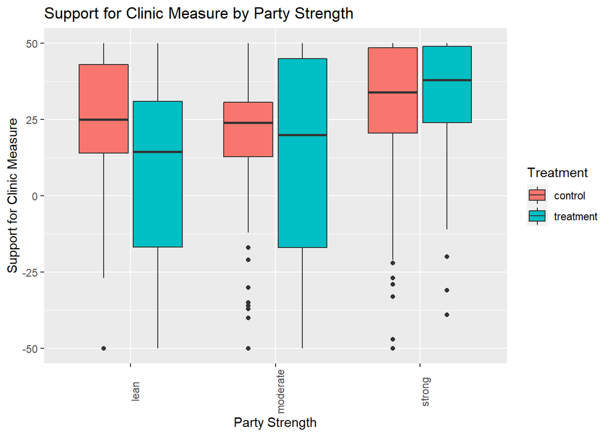

```r
ggplot(final_sm, aes(factor(partyStrength), clinic_Support)) + geom_boxplot(aes(fill = factor(treat))) +
ggtitle("Support for Clinic Measure by Party Strength") + theme(axis.text.x  = element_text(angle=90)) +
  labs(x = "Party Strength", y = "Support for Clinic Measure") +
scale_fill_discrete(name="Treatment", labels=c("control", "treatment"))#, breaks=c(0, 1, 2))
```

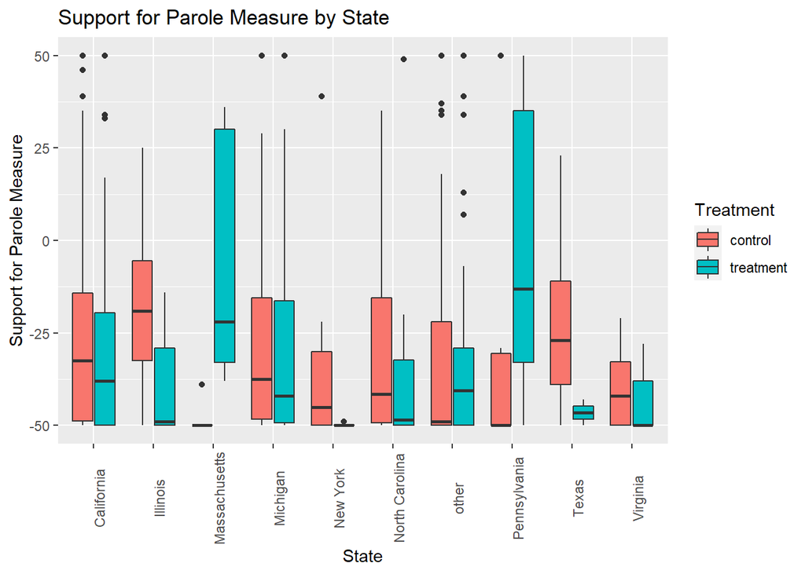

```r
ggplot(final_sm, aes(factor(state_bin), parole_Support)) + geom_boxplot(aes(fill = factor(treat))) +
ggtitle("Support for Parole Measure by State") + theme(axis.text.x  = element_text(angle=90)) +
  labs(x = "State", y = "Support for Parole Measure") +
scale_fill_discrete(name="Treatment", labels=c("control", "treatment"))#, breaks=c(0, 1, 2))
```

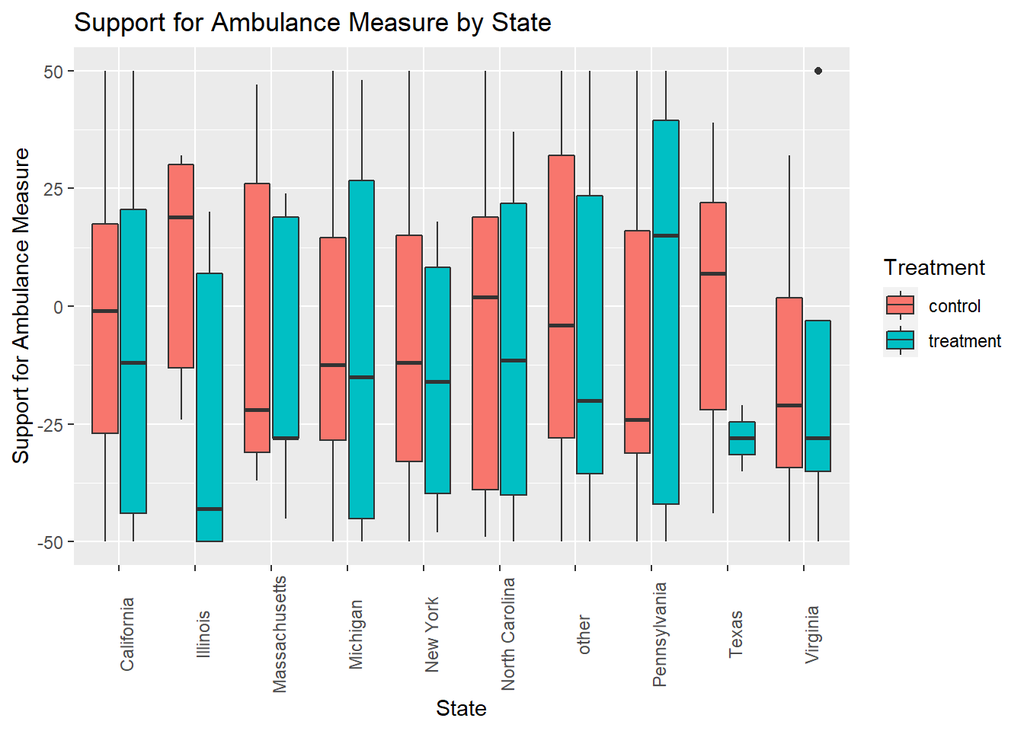

```r
ggplot(final_sm, aes(factor(state_bin), ambulance_Support)) + geom_boxplot(aes(fill = factor(treat))) +
ggtitle("Support for Ambulance Measure by State") + theme(axis.text.x  = element_text(angle=90)) +
  labs(x = "State", y = "Support for Ambulance Measure") +
scale_fill_discrete(name="Treatment", labels=c("control", "treatment"))#, breaks=c(0, 1, 2))
```

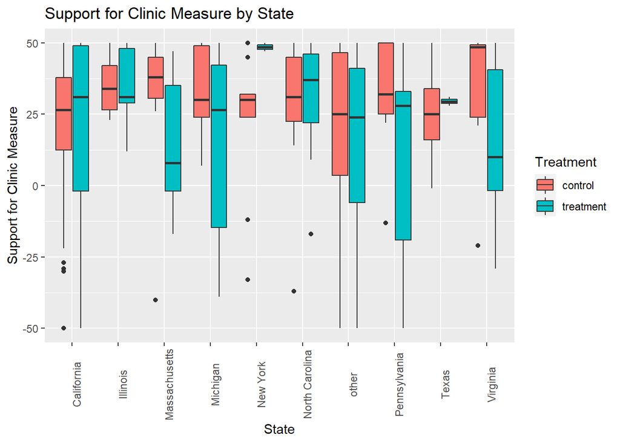

```r
ggplot(final_sm, aes(factor(state_bin), clinic_Support)) + geom_boxplot(aes(fill = factor(treat))) +
ggtitle("Support for Clinic Measure by State") + theme(axis.text.x  = element_text(angle=90)) +
  labs(x = "State", y = "Support for Clinic Measure") +
scale_fill_discrete(name="Treatment", labels=c("control", "treatment"))#, breaks=c(0, 1, 2))
```

## Models with Single Measure Support as Outcome

Let’s start by looking only at the parole measure.

```r
mod_parole_simple <- lm(parole_Support ~ treat, data = final_sm)
mod_parole_party1 <- lm(parole_Support ~ treat + party, data = final_sm)
mod_parole_party2 <- lm(parole_Support ~ treat + party + treat:party, data = final_sm)
mod_parole_partyStrength1 <- lm(parole_Support ~ treat + party + partyStrength, data = final_sm)
mod_parole_partyStrength2 <- lm(parole_Support ~ treat + party + partyStrength + treat:party + treat:partyStrength + party:partyStrength + treat:party:partyStrength, data = final_sm)
mod_parole_education1 <- lm(parole_Support ~ treat + education, data = final_sm)
mod_parole_education2 <- lm(parole_Support ~ treat + education +treat:education, data = final_sm)
mod_parole_income1 <- lm(parole_Support ~ treat + income, data = final_sm)
mod_parole_income2 <- lm(parole_Support ~ treat + income + treat:income, data = final_sm)
mod_parole_age1 <- lm(parole_Support ~ treat + age, data = final_sm)
mod_parole_age2 <- lm(parole_Support ~ treat + age + treat:age, data = final_sm)
mod_parole_gender1 <- lm(parole_Support ~ treat + gender, data = final_sm)
mod_parole_gender2 <- lm(parole_Support ~ treat + gender + treat:gender, data = final_sm)
mod_parole_voting1 <- lm(parole_Support ~ treat + voting, data = final_sm)
mod_parole_voting2 <- lm(parole_Support ~ treat + voting + treat:voting, data = final_sm)
mod_parole_block1 <- lm(parole_Support ~ treat + block, data = final_sm)
mod_parole_block2 <- lm(parole_Support ~ treat + block +treat:block, data = final_sm)

stargazer(
  mod_parole_simple, mod_parole_party1, mod_parole_party2,
  type = 'text',
  header=F
  )
```

```
##
## ========================================================================================
##                                               Dependent variable:
##                        -----------------------------------------------------------------
##                                                 parole_Support
##                                (1)                  (2)                    (3)
## ----------------------------------------------------------------------------------------
## treat                        -0.122                -1.141                 -5.083
##                              (3.047)              (2.920)                (3.776)
##
## partyIndependent                                   6.260*                 1.991
##                                                   (3.399)                (4.788)
##
## partyOther                                         -4.089                 -8.009
##                                                   (6.088)                (7.511)
##
## partyRepublican                                  32.191***              26.184***
##                                                   (5.530)                (7.764)
##
## treat:partyIndependent                                                    8.844
##                                                                          (6.804)
##
## treat:partyOther                                                          10.583
##                                                                          (12.845)
##
## treat:partyRepublican                                                     12.545
##                                                                          (11.067)
##
## Constant                   -28.787***            -32.198***             -30.491***
##                              (2.056)              (2.257)                (2.484)
##
## ----------------------------------------------------------------------------------------
## Observations                   336                  336                    336
## R2                           0.00000               0.099                  0.107
## Adjusted R2                  -0.003                0.088                  0.088
## Residual Std. Error     27.811 (df = 334)    26.516 (df = 331)      26.523 (df = 328)
## F Statistic            0.002 (df = 1; 334) 9.107*** (df = 4; 331) 5.603*** (df = 7; 328)
## ========================================================================================
## Note:                                                        *p<0.1; **p<0.05; ***p<0.01
```

```r
stargazer(
  mod_parole_simple, mod_parole_partyStrength1, mod_parole_partyStrength2,
  type = 'text',
  header=F
  )
```

```
##
## ===============================================================================================================
##                                                                     Dependent variable:
##                                              ------------------------------------------------------------------
##                                                                        parole_Support
##                                                      (1)                  (2)                     (3)
## ---------------------------------------------------------------------------------------------------------------
## treat                                              -0.122                -1.965                 -13.143
##                                                    (3.047)              (2.929)                (10.150)
##
## partyIndependent                                                         3.808                  -1.681
##                                                                         (3.546)                 (9.937)
##
## partyOther                                                               -3.401                 -14.143
##                                                                         (6.062)                (19.503)
##
## partyRepublican                                                        29.618***               41.690***
##                                                                         (5.681)                (12.589)
##
## partyStrengthmoderate                                                    0.451                  -0.917
##                                                                         (4.105)                 (8.308)
##
## partyStrengthstrong                                                     -7.061*                 -7.244
##                                                                         (4.143)                 (7.563)
##
## treat:partyIndependent                                                                          14.143
##                                                                                                (14.333)
##
## treat:partyOther                                                                                 4.577
##                                                                                                (14.796)
##
## treat:partyRepublican                                                                            6.643
##                                                                                                (18.025)
##
## treat:partyStrengthmoderate                                                                     13.207
##                                                                                                (12.081)
##
## treat:partyStrengthstrong                                                                        5.358
##                                                                                                (11.304)
##
```

[output cut: 32 more lines]

```
##
## treat:partyRepublican:partyStrengthstrong
##
##
## Constant                                         -28.787***            -28.011***             -25.857***
##                                                    (2.056)              (4.011)                 (6.895)
##
## ---------------------------------------------------------------------------------------------------------------
## Observations                                         336                  336                     336
## R2                                                 0.00000               0.114                   0.191
## Adjusted R2                                        -0.003                0.098                   0.137
## Residual Std. Error                           27.811 (df = 334)    26.372 (df = 329)       25.800 (df = 314)
## F Statistic                                  0.002 (df = 1; 334) 7.076*** (df = 6; 329) 3.529*** (df = 21; 314)
## ===============================================================================================================
## Note:                                                                               *p<0.1; **p<0.05; ***p<0.01
```

```r
stargazer(
  mod_parole_simple, mod_parole_block1, mod_parole_block2,
  type = 'text',
  header=F
  )
```

```
##
## ===============================================================================
##                                         Dependent variable:
##                     -----------------------------------------------------------
##                                           parole_Support
##                             (1)                 (2)                 (3)
## -------------------------------------------------------------------------------
## treat                     -0.122              -0.265              -7.750
##                           (3.047)             (3.049)             (6.089)
##
## block                                          0.877              -0.202
##                                               (0.809)             (1.110)
##
## treat:block                                                        2.299
##                                                                   (1.620)
##
## Constant                -28.787***          -31.567***          -28.146***
##                           (2.056)             (3.287)             (4.072)
##
## -------------------------------------------------------------------------------
## Observations                336                 336                 336
## R2                        0.00000              0.004               0.010
## Adjusted R2               -0.003              -0.002               0.001
## Residual Std. Error  27.811 (df = 334)   27.804 (df = 333)   27.762 (df = 332)
## F Statistic         0.002 (df = 1; 334) 0.588 (df = 2; 333) 1.065 (df = 3; 332)
## ===============================================================================
## Note:                                               *p<0.1; **p<0.05; ***p<0.01
```

```r
stargazer(
  mod_parole_simple, mod_parole_education1, mod_parole_education2,
  type = 'text',
  header=F
  )
```

```
##
## ====================================================================================================
##                                                          Dependent variable:
##                                   ------------------------------------------------------------------
##                                                             parole_Support
##                                           (1)                  (2)                     (3)
## ----------------------------------------------------------------------------------------------------
## treat                                   -0.122                -0.666                 -2.901
##                                         (3.047)              (2.995)                 (4.492)
##
## education2: high school                                       29.231                 27.857
##                                                              (28.337)               (29.071)
##
## education3: some college                                      30.637                 29.857
##                                                              (27.557)               (27.675)
##
## education4: college degree                                    26.426                 22.156
##                                                              (27.472)               (27.494)
##
## education5: some post-grad                                    14.461                 22.333
##                                                              (27.708)               (27.938)
##
## education6: graduate degree                                   16.311                 17.286
##                                                              (27.397)               (27.355)
##
## treat:education2: high school                                                         5.211
##                                                                                     (15.782)
##
## treat:education3: some college                                                        3.794
##                                                                                      (8.544)
##
## treat:education4: college degree                                                     11.561
##                                                                                      (7.488)
##
## treat:education5: some post-grad                                                     -14.495
##                                                                                     (10.367)
##
## treat:education6: graduate degree
##
##
## Constant                              -28.787***             -50.000*               -50.000*
##                                         (2.056)              (27.274)               (27.193)
##
## ----------------------------------------------------------------------------------------------------
## Observations                              336                  336                     336
## R2                                      0.00000               0.053                   0.070
## Adjusted R2                             -0.003                0.035                   0.041
## Residual Std. Error                27.811 (df = 334)    27.274 (df = 329)       27.193 (df = 325)
## F Statistic                       0.002 (df = 1; 334) 3.047*** (df = 6; 329) 2.435*** (df = 10; 325)
## ====================================================================================================
## Note:                                                                    *p<0.1; **p<0.05; ***p<0.01
```

```r
stargazer(
  mod_parole_simple, mod_parole_income1,  mod_parole_income2,
  type = 'text',
  header=F
  )
```

```
##
## ===============================================================================
##                                         Dependent variable:
##                     -----------------------------------------------------------
##                                           parole_Support
##                             (1)                 (2)                 (3)
## -------------------------------------------------------------------------------
## treat                     -0.122              -0.005              -2.393
##                           (3.047)             (3.056)             (7.451)
##
## 100k                                           3.952               0.450
##                                               (4.655)             (6.416)
##
## 100k                                           4.132               3.974
##                                               (4.264)             (5.981)
##
## 100k                                                               7.884
##                                                                   (9.351)
##
## 100k                                                               0.141
##                                                                   (8.538)
##
## Constant                -28.787***          -32.229***          -31.036***
##                           (2.056)             (4.023)             (5.269)
##
## -------------------------------------------------------------------------------
## Observations                336                 336                 336
## R2                        0.00000              0.003               0.007
## Adjusted R2               -0.003              -0.006              -0.008
## Residual Std. Error  27.811 (df = 334)   27.853 (df = 332)   27.881 (df = 330)
## F Statistic         0.002 (df = 1; 334) 0.333 (df = 3; 332) 0.467 (df = 5; 330)
## ===============================================================================
## Note:                                               *p<0.1; **p<0.05; ***p<0.01
```

```r
stargazer(
  mod_parole_simple, mod_parole_voting1, mod_parole_voting2,
  type = 'text',
  header=F
  )
```

```
##
## =========================================================================================
##                                                  Dependent variable:
##                              ------------------------------------------------------------
##                                                     parole_Support
##                                      (1)                 (2)                  (3)
## -----------------------------------------------------------------------------------------
## treat                              -0.122               -0.083              -1.333
##                                    (3.047)             (3.028)             (11.290)
##
## voting2: every 4 years                                  -4.796              -7.893
##                                                        (7.314)             (10.007)
##
## voting3: every 2 years                                -14.225**             -12.447
##                                                        (6.752)              (9.322)
##
## voting4: always vote                                  -14.279**            -15.203*
##                                                        (5.925)              (8.382)
##
## treat:voting2: every 4 years                                                 7.429
##                                                                            (14.782)
##
## treat:voting3: every 2 years                                                -4.758
##                                                                            (13.616)
##
## treat:voting4: always vote                                                   1.882
##                                                                            (11.886)
##
## Constant                         -28.787***           -16.542***           -15.917**
##                                    (2.056)             (5.828)              (7.983)
##
## -----------------------------------------------------------------------------------------
## Observations                         336                 336                  336
## R2                                 0.00000              0.026                0.029
## Adjusted R2                        -0.003               0.014                0.008
## Residual Std. Error           27.811 (df = 334)   27.574 (df = 331)    27.654 (df = 328)
## F Statistic                  0.002 (df = 1; 334) 2.195* (df = 4; 331) 1.402 (df = 7; 328)
## =========================================================================================
## Note:                                                         *p<0.1; **p<0.05; ***p<0.01
```

```r
stargazer(
  mod_parole_simple, mod_parole_age1, mod_parole_age2,
  type = 'text',
  header=F
  )
```

```
##
## ===============================================================================
##                                         Dependent variable:
##                     -----------------------------------------------------------
##                                           parole_Support
##                             (1)                 (2)                 (3)
## -------------------------------------------------------------------------------
## treat                     -0.122              -0.139              -11.690
##                           (3.047)             (3.051)            (10.166)
##
## age                                           -0.043              -0.190
##                                               (0.123)             (0.175)
##
## treat:age                                                          0.294
##                                                                   (0.247)
##
## Constant                -28.787***          -27.090***          -21.277***
##                           (2.056)             (5.294)             (7.198)
##
## -------------------------------------------------------------------------------
## Observations                336                 336                 336
## R2                        0.00000             0.0004               0.005
## Adjusted R2               -0.003              -0.006              -0.004
## Residual Std. Error  27.811 (df = 334)   27.848 (df = 333)   27.830 (df = 332)
## F Statistic         0.002 (df = 1; 334) 0.061 (df = 2; 333) 0.514 (df = 3; 332)
## ===============================================================================
## Note:                                               *p<0.1; **p<0.05; ***p<0.01
```

```r
stargazer(
  mod_parole_simple, mod_parole_gender1, mod_parole_gender2,
  type = 'text',
  header=F
  )
```

```
##
## ========================================================================================================
##                                                               Dependent variable:
##                                         ----------------------------------------------------------------
##                                                                  parole_Support
##                                                 (1)                  (2)                    (3)
## --------------------------------------------------------------------------------------------------------
## treat                                         -0.122                0.534                  1.649
##                                               (3.047)              (3.002)                (3.849)
##
## genderMale                                                          2.495                  3.624
##                                                                    (3.110)                (4.277)
##
## genderNonbinary/Transgender/Other                                  -10.328                -4.553
##                                                                    (12.364)              (16.014)
##
## genderPrefer not to say                                           72.786***              73.281***
##                                                                    (19.454)              (19.529)
##
## treat:genderMale                                                                          -2.426
##                                                                                           (6.247)
##
## treat:genderNonbinary/Transgender/Other                                                   -14.316
##                                                                                          (25.288)
##
## treat:genderPrefer not to say
##
##
## Constant                                    -28.787***            -30.286***            -30.781***
##                                               (2.056)              (2.327)                (2.564)
##
## --------------------------------------------------------------------------------------------------------
## Observations                                    336                  336                    336
## R2                                            0.00000               0.044                  0.045
## Adjusted R2                                   -0.003                0.033                  0.028
## Residual Std. Error                      27.811 (df = 334)    27.315 (df = 331)      27.379 (df = 329)
## F Statistic                             0.002 (df = 1; 334) 3.814*** (df = 4; 331) 2.603** (df = 6; 329)
## ========================================================================================================
## Note:                                                                        *p<0.1; **p<0.05; ***p<0.01
```

> The most interesting is voting habits. Being a more engaged voter is an indicator of how you will vote. But, taking away the variance of voting habits does not make the treatment effect more pronounced.

Now let’s do the same models with the Clinic measure.

```r
mod_clinic_simple <- lm(clinic_Support ~ treat, data = final_sm)
mod_clinic_party1 <- lm(clinic_Support ~ treat + party, data = final_sm)
mod_clinic_party2 <- lm(clinic_Support ~ treat + party + treat:party, data = final_sm)
mod_clinic_partyStrength1 <- lm(clinic_Support ~ treat + party + partyStrength, data = final_sm)
mod_clinic_partyStrength2 <- lm(clinic_Support ~ treat + party + partyStrength + treat:party + treat:partyStrength + party:partyStrength + treat:party:partyStrength, data = final_sm)
mod_clinic_education1 <- lm(clinic_Support ~ treat + education, data = final_sm)
mod_clinic_education2 <- lm(clinic_Support ~ treat + education +treat:education, data = final_sm)
mod_clinic_income1 <- lm(clinic_Support ~ treat + income, data = final_sm)
mod_clinic_income2 <- lm(clinic_Support ~ treat + income + treat:income, data = final_sm)
mod_clinic_age1 <- lm(clinic_Support ~ treat + age, data = final_sm)
mod_clinic_age2 <- lm(clinic_Support ~ treat + age + treat:age, data = final_sm)
mod_clinic_gender1 <- lm(clinic_Support ~ treat + gender, data = final_sm)
mod_clinic_gender2 <- lm(clinic_Support ~ treat + gender + treat:gender, data = final_sm)
mod_clinic_voting1 <- lm(clinic_Support ~ treat + voting, data = final_sm)
mod_clinic_voting2 <- lm(clinic_Support ~ treat + voting + treat:voting, data = final_sm)
mod_clinic_block1 <- lm(clinic_Support ~ treat + block, data = final_sm)
mod_clinic_block2 <- lm(clinic_Support ~ treat + block +treat:block, data = final_sm)

stargazer(
  mod_clinic_simple, mod_clinic_party1, mod_clinic_party2,
  type = 'text',
  header=F
  )
```

```
##
## ========================================================================================
##                                               Dependent variable:
##                        -----------------------------------------------------------------
##                                                 clinic_Support
##                                (1)                  (2)                    (3)
## ----------------------------------------------------------------------------------------
## treat                        -3.717                -2.793                 -5.407
##                              (3.103)              (3.069)                (3.933)
##
## partyIndependent                                  -8.319**              -13.669***
##                                                   (3.580)                (5.025)
##
## partyOther                                         -5.080                -11.047
##                                                   (6.383)                (7.830)
##
## partyRepublican                                  -20.307***              -12.047
##                                                   (5.904)                (8.392)
##
## treat:partyIndependent                                                    10.638
##                                                                          (7.129)
##
## treat:partyOther                                                          17.193
##                                                                          (13.406)
##
## treat:partyRepublican                                                    -15.400
##                                                                          (11.761)
##
## Constant                    22.875***            26.440***              27.547***
##                              (2.087)              (2.346)                (2.560)
##
## ----------------------------------------------------------------------------------------
## Observations                   336                  336                    336
## R2                            0.004                0.047                  0.065
## Adjusted R2                   0.001                0.035                  0.045
## Residual Std. Error     28.309 (df = 334)    27.821 (df = 331)      27.687 (df = 328)
## F Statistic            1.435 (df = 1; 334) 4.077*** (df = 4; 331) 3.238*** (df = 7; 328)
## ========================================================================================
## Note:                                                        *p<0.1; **p<0.05; ***p<0.01
```

```r
stargazer(
  mod_clinic_simple, mod_clinic_partyStrength1, mod_clinic_partyStrength2,
  type = 'text',
  header=F
  )
```

```
##
## ===============================================================================================================
##                                                                     Dependent variable:
##                                              ------------------------------------------------------------------
##                                                                        clinic_Support
##                                                      (1)                  (2)                     (3)
## ---------------------------------------------------------------------------------------------------------------
## treat                                              -3.717                -1.547                 -7.800
##                                                    (3.103)              (3.055)                (10.197)
##
## partyIndependent                                                         -5.229                  5.700
##                                                                         (3.681)                (10.197)
##
## partyOther                                                               -6.097                -41.633**
##                                                                         (6.308)                (19.819)
##
## partyRepublican                                                        -17.355***                5.200
##                                                                         (5.989)                (12.717)
##
## partyStrengthmoderate                                                    -3.199                 -0.633
##                                                                         (4.286)                 (8.238)
##
## partyStrengthstrong                                                      8.168*                  9.338
##                                                                         (4.296)                 (7.491)
##
## treat:partyIndependent                                                                          -14.726
##                                                                                                (14.665)
##
## treat:partyOther                                                                                14.267
##                                                                                                (15.106)
##
## treat:partyRepublican                                                                           -11.333
##                                                                                                (18.924)
##
## treat:partyStrengthmoderate                                                                     -1.055
##                                                                                                (12.165)
##
## treat:partyStrengthstrong                                                                        7.491
##                                                                                                (11.401)
##
```

[output cut: 32 more lines]

```
##
## treat:partyRepublican:partyStrengthstrong
##
##
## Constant                                          22.875***            22.358***               22.133***
##                                                    (2.087)              (4.137)                 (6.798)
##
## ---------------------------------------------------------------------------------------------------------------
## Observations                                         336                  336                     336
## R2                                                  0.004                0.077                   0.190
## Adjusted R2                                         0.001                0.061                   0.136
## Residual Std. Error                           28.309 (df = 334)    27.455 (df = 329)       26.328 (df = 314)
## F Statistic                                  1.435 (df = 1; 334) 4.602*** (df = 6; 329) 3.515*** (df = 21; 314)
## ===============================================================================================================
## Note:                                                                               *p<0.1; **p<0.05; ***p<0.01
```

```r
stargazer(
  mod_clinic_simple, mod_clinic_block1, mod_clinic_block2,
  type = 'text',
  header=F
  )
```

```
##
## ===================================================================================
##                                           Dependent variable:
##                     ---------------------------------------------------------------
##                                             clinic_Support
##                             (1)                  (2)                   (3)
## -----------------------------------------------------------------------------------
## treat                     -3.717               -3.278               -14.114**
##                           (3.103)              (3.087)               (6.141)
##
## block                                         -1.955**              -3.526***
##                                                (0.821)               (1.123)
##
## treat:block                                                          3.335**
##                                                                      (1.636)
##
## Constant                 22.875***            28.995***             33.912***
##                           (2.087)              (3.301)               (4.076)
##
## -----------------------------------------------------------------------------------
## Observations                336                  336                   336
## R2                         0.004                0.021                 0.033
## Adjusted R2                0.001                0.015                 0.024
## Residual Std. Error  28.309 (df = 334)    28.113 (df = 333)     27.980 (df = 332)
## F Statistic         1.435 (df = 1; 334) 3.566** (df = 2; 333) 3.784** (df = 3; 332)
## ===================================================================================
## Note:                                                   *p<0.1; **p<0.05; ***p<0.01
```

```r
stargazer(
  mod_clinic_simple, mod_clinic_education1, mod_clinic_education2,
  type = 'text',
  header=F
  )
```

```
##
## ===============================================================================================
##                                                        Dependent variable:
##                                   -------------------------------------------------------------
##                                                          clinic_Support
##                                           (1)                 (2)                  (3)
## -----------------------------------------------------------------------------------------------
## treat                                   -3.717              -3.893                0.807
##                                         (3.103)             (3.094)              (4.655)
##
## education2: high school                                     -37.628              -22.857
##                                                            (29.335)             (29.913)
##
## education3: some college                                    -27.125              -22.750
##                                                            (28.452)             (28.477)
##
## education4: college degree                                  -25.542              -27.750
##                                                            (28.352)             (28.271)
##
## education5: some post-grad                                  -16.759              -13.824
##                                                            (28.610)             (28.793)
##
## education6: graduate degree                                 -29.604              -31.651
##                                                            (28.284)             (28.150)
##
## treat:education2: high school                                                   -40.150**
##                                                                                 (17.033)
##
## treat:education3: some college                                                   -13.612
##                                                                                  (8.867)
##
## treat:education4: college degree                                                  0.225
##                                                                                  (7.619)
##
## treat:education5: some post-grad                                                 -10.572
##                                                                                 (10.667)
##
## treat:education6: graduate degree
##
##
## Constant                               22.875***            50.000*              50.000*
##                                         (2.087)            (28.157)             (27.981)
##
## -----------------------------------------------------------------------------------------------
## Observations                              336                 336                  336
## R2                                       0.004               0.030                0.053
## Adjusted R2                              0.001               0.012                0.024
## Residual Std. Error                28.309 (df = 334)   28.157 (df = 329)    27.981 (df = 325)
## F Statistic                       1.435 (df = 1; 334) 1.678 (df = 6; 329) 1.833* (df = 10; 325)
## ===============================================================================================
## Note:                                                               *p<0.1; **p<0.05; ***p<0.01
```

```r
stargazer(
  mod_clinic_simple, mod_clinic_income1,  mod_clinic_income2,
  type = 'text',
  header=F
  )
```

```
##
## ===================================================================================
##                                           Dependent variable:
##                     ---------------------------------------------------------------
##                                             clinic_Support
##                             (1)                  (2)                   (3)
## -----------------------------------------------------------------------------------
## treat                     -3.717               -4.130                -10.959
##                           (3.103)              (3.073)               (7.487)
##
## 100k                                           -8.846*              -14.425**
##                                                (4.679)               (6.522)
##
## 100k                                         -13.396***            -16.700***
##                                                (4.286)               (6.078)
##
## 100k                                                                 11.691
##                                                                      (9.393)
##
## 100k                                                                  6.314
##                                                                      (8.582)
##
## Constant                 22.875***            32.871***             36.407***
##                           (2.087)              (4.063)               (5.388)
##
## -----------------------------------------------------------------------------------
## Observations                336                  336                   336
## R2                         0.004                0.033                 0.038
## Adjusted R2                0.001                0.024                 0.023
## Residual Std. Error  28.309 (df = 334)    27.978 (df = 332)     27.996 (df = 330)
## F Statistic         1.435 (df = 1; 334) 3.804** (df = 3; 332) 2.596** (df = 5; 330)
## ===================================================================================
## Note:                                                   *p<0.1; **p<0.05; ***p<0.01
```

```r
stargazer(
  mod_clinic_simple, mod_clinic_voting1, mod_clinic_voting2,
  type = 'text',
  header=F
  )
```

```
##
## ========================================================================================
##                                                  Dependent variable:
##                              -----------------------------------------------------------
##                                                    clinic_Support
##                                      (1)                 (2)                 (3)
## ----------------------------------------------------------------------------------------
## treat                              -3.717              -3.699              -9.936
##                                    (3.103)             (3.128)            (11.403)
##
## voting2: every 4 years                                  5.213               1.024
##                                                        (7.449)            (10.308)
##
## voting3: every 2 years                                  1.667              -4.139
##                                                        (6.831)             (9.495)
##
## voting4: always vote                                    3.249               0.642
##                                                        (5.999)             (8.641)
##
## treat:voting2: every 4 years                                                8.603
##                                                                           (15.054)
##
## treat:voting3: every 2 years                                               13.194
##                                                                           (13.827)
##
## treat:voting4: always vote                                                  4.896
##                                                                           (12.037)
##
## Constant                          22.875***           19.923***           23.167***
##                                    (2.087)             (5.910)             (8.223)
##
## ----------------------------------------------------------------------------------------
## Observations                         336                 336                 336
## R2                                  0.004               0.006               0.010
## Adjusted R2                         0.001              -0.006              -0.011
## Residual Std. Error           28.309 (df = 334)   28.410 (df = 331)   28.484 (df = 328)
## F Statistic                  1.435 (df = 1; 334) 0.514 (df = 4; 331) 0.474 (df = 7; 328)
## ========================================================================================
## Note:                                                        *p<0.1; **p<0.05; ***p<0.01
```

```r
stargazer(
  mod_clinic_simple, mod_clinic_age1, mod_clinic_age2,
  type = 'text',
  header=F
  )
```

```
##
## ===============================================================================
##                                         Dependent variable:
##                     -----------------------------------------------------------
##                                           clinic_Support
##                             (1)                 (2)                 (3)
## -------------------------------------------------------------------------------
## treat                     -3.717              -3.715              -4.713
##                           (3.103)             (3.107)            (10.438)
##
## age                                            0.028               0.015
##                                               (0.126)             (0.179)
##
## treat:age                                                          0.025
##                                                                   (0.253)
##
## Constant                 22.875***           21.773***           22.273***
##                           (2.087)             (5.399)             (7.364)
##
## -------------------------------------------------------------------------------
## Observations                336                 336                 336
## R2                         0.004               0.004               0.004
## Adjusted R2                0.001              -0.002              -0.005
## Residual Std. Error  28.309 (df = 334)   28.349 (df = 333)   28.391 (df = 332)
## F Statistic         1.435 (df = 1; 334) 0.740 (df = 2; 333) 0.495 (df = 3; 332)
## ===============================================================================
## Note:                                               *p<0.1; **p<0.05; ***p<0.01
```

```r
stargazer(
  mod_clinic_simple, mod_clinic_gender1, mod_clinic_gender2,
  type = 'text',
  header=F
  )
```

```
##
## ===================================================================================================
##                                                             Dependent variable:
##                                         -----------------------------------------------------------
##                                                               clinic_Support
##                                                 (1)                 (2)                 (3)
## ---------------------------------------------------------------------------------------------------
## treat                                         -3.717              -3.890              -3.164
##                                               (3.103)             (3.109)             (3.978)
##
## genderMale                                                        -3.276              -2.363
##                                                                   (3.224)             (4.422)
##
## genderNonbinary/Transgender/Other                                  9.157               9.122
##                                                                  (12.797)            (16.582)
##
## genderPrefer not to say                                           -30.699             -30.378
##                                                                  (20.135)            (20.222)
##
## treat:genderMale                                                                      -1.962
##                                                                                       (6.482)
##
## treat:genderNonbinary/Transgender/Other                                                0.164
##                                                                                      (26.187)
##
## treat:genderPrefer not to say
##
##
## Constant                                     22.875***           24.199***           23.878***
##                                               (2.087)             (2.401)             (2.644)
##
## ---------------------------------------------------------------------------------------------------
## Observations                                    336                 336                 336
## R2                                             0.004               0.016               0.016
## Adjusted R2                                    0.001               0.004              -0.002
## Residual Std. Error                      28.309 (df = 334)   28.272 (df = 331)   28.353 (df = 329)
## F Statistic                             1.435 (df = 1; 334) 1.329 (df = 4; 331) 0.897 (df = 6; 329)
## ===================================================================================================
## Note:                                                                   *p<0.1; **p<0.05; ***p<0.01
```

Finally, we can take a look at the ambulance measure.

```r
mod_ambulance_simple <- lm(ambulance_Support ~ treat, data = final_sm)
mod_ambulance_party1 <- lm(ambulance_Support ~ treat + party, data = final_sm)
mod_ambulance_party2 <- lm(ambulance_Support ~ treat + party + treat:party, data = final_sm)
mod_ambulance_partyStrength1 <- lm(ambulance_Support ~ treat + party + partyStrength, data = final_sm)
mod_ambulance_partyStrength2 <- lm(ambulance_Support ~ treat + party + partyStrength + treat:party + treat:partyStrength + party:partyStrength + treat:party:partyStrength, data = final_sm)
mod_ambulance_education1 <- lm(ambulance_Support ~ treat + education, data = final_sm)
mod_ambulance_education2 <- lm(ambulance_Support ~ treat + education +treat:education, data = final_sm)
mod_ambulance_income1 <- lm(ambulance_Support ~ treat + income, data = final_sm)
mod_ambulance_income2 <- lm(ambulance_Support ~ treat + income + treat:income, data = final_sm)
mod_ambulance_age1 <- lm(ambulance_Support ~ treat + age, data = final_sm)
mod_ambulance_age2 <- lm(ambulance_Support ~ treat + age + treat:age, data = final_sm)
mod_ambulance_gender1 <- lm(ambulance_Support ~ treat + gender, data = final_sm)
mod_ambulance_gender2 <- lm(ambulance_Support ~ treat + gender + treat:gender, data = final_sm)
mod_ambulance_voting1 <- lm(ambulance_Support ~ treat + voting, data = final_sm)
mod_ambulance_voting2 <- lm(ambulance_Support ~ treat + voting + treat:voting, data = final_sm)
mod_ambulance_block1 <- lm(ambulance_Support ~ treat + block, data = final_sm)
mod_ambulance_block2 <- lm(ambulance_Support ~ treat + block +treat:block, data = final_sm)

stargazer(
  mod_ambulance_simple, mod_ambulance_party1, mod_ambulance_party2,
  type = 'text',
  header=F
  )
```

```
##
## =====================================================================================
##                                             Dependent variable:
##                        --------------------------------------------------------------
##                                              ambulance_Support
##                                (1)                  (2)                  (3)
## -------------------------------------------------------------------------------------
## treat                        -5.527               -6.200*              -8.570*
##                              (3.608)              (3.587)              (4.679)
##
## partyIndependent                                  -0.278                -3.179
##                                                   (4.169)              (5.837)
##
## partyOther                                       -15.545**             -17.799*
##                                                   (7.532)              (9.321)
##
## partyRepublican                                  14.536**               12.272
##                                                   (6.622)              (9.321)
##
## treat:partyIndependent                                                  6.050
##                                                                        (8.373)
##
## treat:partyOther                                                        6.070
##                                                                        (15.946)
##
## treat:partyRepublican                                                   4.856
##                                                                        (13.297)
##
## Constant                     -3.005               -2.864                -1.843
##                              (2.425)              (2.778)              (3.071)
##
## -------------------------------------------------------------------------------------
## Observations                   341                  341                  341
## R2                            0.007                0.036                0.038
## Adjusted R2                   0.004                0.025                0.018
## Residual Std. Error     33.159 (df = 339)    32.814 (df = 336)    32.930 (df = 333)
## F Statistic            2.346 (df = 1; 339) 3.141** (df = 4; 336) 1.873* (df = 7; 333)
## =====================================================================================
## Note:                                                     *p<0.1; **p<0.05; ***p<0.01
```

```r
stargazer(
  mod_ambulance_simple, mod_ambulance_partyStrength1, mod_ambulance_partyStrength2,
  type = 'text',
  header=F
  )
```

```
##
## ==============================================================================================================
##                                                                     Dependent variable:
##                                              -----------------------------------------------------------------
##                                                                      ambulance_Support
##                                                      (1)                  (2)                    (3)
## --------------------------------------------------------------------------------------------------------------
## treat                                              -5.527               -7.223**               -15.274
##                                                    (3.608)              (3.602)                (12.744)
##
## partyIndependent                                                         -0.844                 2.500
##                                                                         (4.339)                (12.244)
##
## partyOther                                                             -15.204**                16.643
##                                                                         (7.497)                (24.488)
##
## partyRepublican                                                         15.732**                11.000
##                                                                         (6.800)                (14.996)
##
## partyStrengthmoderate                                                   11.165**                3.562
##                                                                         (5.036)                (10.431)
##
## partyStrengthstrong                                                      3.570                  2.200
##                                                                         (5.061)                (9.484)
##
## treat:partyIndependent                                                                          -2.160
##                                                                                                (17.835)
##
## treat:partyOther                                                                                5.135
##                                                                                                (18.587)
##
## treat:partyRepublican                                                                          -11.750
##                                                                                                (22.073)
##
## treat:partyStrengthmoderate                                                                     14.636
##                                                                                                (15.134)
##
## treat:partyStrengthstrong                                                                       2.472
##                                                                                                (14.206)
##
```

[output cut: 32 more lines]

```
##
## treat:partyRepublican:partyStrengthstrong                                                       55.551
##                                                                                                (42.260)
##
## Constant                                           -3.005                -7.903                 -4.143
##                                                    (2.425)              (4.903)                (8.658)
##
## --------------------------------------------------------------------------------------------------------------
## Observations                                         341                  341                    341
## R2                                                  0.007                0.053                  0.111
## Adjusted R2                                         0.004                0.036                  0.049
## Residual Std. Error                           33.159 (df = 339)    32.624 (df = 334)      32.394 (df = 318)
## F Statistic                                  2.346 (df = 1; 339) 3.107*** (df = 6; 334) 1.803** (df = 22; 318)
## ==============================================================================================================
## Note:                                                                              *p<0.1; **p<0.05; ***p<0.01
```

```r
stargazer(
  mod_ambulance_simple, mod_ambulance_block1, mod_ambulance_block2,
  type = 'text',
  header=F
  )
```

```
##
## ===============================================================================
##                                         Dependent variable:
##                     -----------------------------------------------------------
##                                          ambulance_Support
##                             (1)                 (2)                 (3)
## -------------------------------------------------------------------------------
## treat                     -5.527              -5.411             -12.266*
##                           (3.608)             (3.613)             (7.257)
##
## block                                         -0.802              -1.776
##                                               (0.960)             (1.312)
##
## treat:block                                                        2.096
##                                                                   (1.925)
##
## Constant                  -3.005              -0.445               2.664
##                           (2.425)             (3.909)             (4.840)
##
## -------------------------------------------------------------------------------
## Observations                341                 341                 341
## R2                         0.007               0.009               0.012
## Adjusted R2                0.004               0.003               0.004
## Residual Std. Error  33.159 (df = 339)   33.174 (df = 338)   33.165 (df = 337)
## F Statistic         2.346 (df = 1; 339) 1.521 (df = 2; 338) 1.410 (df = 3; 337)
## ===============================================================================
## Note:                                               *p<0.1; **p<0.05; ***p<0.01
```

```r
stargazer(
  mod_ambulance_simple, mod_ambulance_education1, mod_ambulance_education2,
  type = 'text',
  header=F
  )
```

```
##
## ==============================================================================================
##                                                       Dependent variable:
##                                   ------------------------------------------------------------
##                                                        ambulance_Support
##                                           (1)                 (2)                 (3)
## ----------------------------------------------------------------------------------------------
## treat                                   -5.527              -5.333               -7.025
##                                         (3.608)             (3.620)             (5.506)
##
## education2: high school                                     -48.000             -55.714
##                                                            (34.486)             (35.473)
##
## education3: some college                                    -50.380             -46.448
##                                                            (33.529)             (33.749)
##
## education4: college degree                                  -52.065             -56.312*
##                                                            (33.421)             (33.526)
##
## education5: some post-grad                                 -58.079*             -53.500
##                                                            (33.720)             (34.091)
##
## education6: graduate degree                                 -54.410             -53.679
##                                                            (33.341)             (33.379)
##
## treat:education2: high school                                                    18.406
##                                                                                 (19.264)
##
## treat:education3: some college                                                   -6.313
##                                                                                 (10.373)
##
## treat:education4: college degree                                                 11.037
##                                                                                 (8.988)
##
## treat:education5: some post-grad                                                 -8.038
##                                                                                 (12.661)
##
## treat:education6: graduate degree
##
##
## Constant                                -3.005              50.000               50.000
##                                         (2.425)            (33.192)             (33.182)
##
## ----------------------------------------------------------------------------------------------
## Observations                              341                 341                 341
## R2                                       0.007               0.020               0.032
## Adjusted R2                              0.004               0.002               0.003
## Residual Std. Error                33.159 (df = 339)   33.192 (df = 334)   33.182 (df = 330)
## F Statistic                       2.346 (df = 1; 339) 1.111 (df = 6; 334) 1.087 (df = 10; 330)
## ==============================================================================================
## Note:                                                              *p<0.1; **p<0.05; ***p<0.01
```

```r
stargazer(
  mod_ambulance_simple, mod_ambulance_income1,  mod_ambulance_income2,
  type = 'text',
  header=F
  )
```

```
##
## ==================================================================================
##                                          Dependent variable:
##                     --------------------------------------------------------------
##                                           ambulance_Support
##                             (1)                  (2)                  (3)
## ----------------------------------------------------------------------------------
## treat                     -5.527               -5.020                -4.586
##                           (3.608)              (3.579)              (8.648)
##
## 100k                                          14.802***             14.082*
##                                                (5.419)              (7.468)
##
## 100k                                          13.165***             14.003**
##                                                (4.955)              (6.953)
##
## 100k                                                                 1.818
##                                                                     (10.908)
##
## 100k                                                                 -1.796
##                                                                     (9.940)
##
## Constant                  -3.005             -14.645***            -14.862**
##                           (2.425)              (4.669)              (6.115)
##
## ----------------------------------------------------------------------------------
## Observations                341                  341                  341
## R2                         0.007                0.032                0.032
## Adjusted R2                0.004                0.023                0.018
## Residual Std. Error  33.159 (df = 339)    32.842 (df = 337)    32.931 (df = 335)
## F Statistic         2.346 (df = 1; 339) 3.657** (df = 3; 337) 2.221* (df = 5; 335)
## ==================================================================================
## Note:                                                  *p<0.1; **p<0.05; ***p<0.01
```

```r
stargazer(
  mod_ambulance_simple, mod_ambulance_voting1, mod_ambulance_voting2,
  type = 'text',
  header=F
  )
```

```
##
## ========================================================================================
##                                                  Dependent variable:
##                              -----------------------------------------------------------
##                                                   ambulance_Support
##                                      (1)                 (2)                 (3)
## ----------------------------------------------------------------------------------------
## treat                              -5.527              -5.330              -6.385
##                                    (3.608)             (3.630)            (13.082)
##
## voting2: every 4 years                                 -2.368              -0.521
##                                                        (8.562)            (11.668)
##
## voting3: every 2 years                                 -2.818              -2.218
##                                                        (7.855)            (10.792)
##
## voting4: always vote                                   -6.515              -7.902
##                                                        (6.891)             (9.755)
##
## treat:voting2: every 4 years                                               -5.050
##                                                                           (17.354)
##
## treat:voting3: every 2 years                                               -1.918
##                                                                           (15.894)
##
## treat:voting4: always vote                                                  2.864
##                                                                           (13.832)
##
## Constant                           -3.005               1.857               2.385
##                                    (2.425)             (6.765)             (9.250)
##
## ----------------------------------------------------------------------------------------
## Observations                         341                 341                 341
## R2                                  0.007               0.011               0.013
## Adjusted R2                         0.004              -0.0004             -0.008
## Residual Std. Error           33.159 (df = 339)   33.232 (df = 336)   33.353 (df = 333)
## F Statistic                  2.346 (df = 1; 339) 0.964 (df = 4; 336) 0.627 (df = 7; 333)
## ========================================================================================
## Note:                                                        *p<0.1; **p<0.05; ***p<0.01
```

```r
stargazer(
  mod_ambulance_simple, mod_ambulance_age1, mod_ambulance_age2,
  type = 'text',
  header=F
  )
```

```
##
## ===============================================================================
##                                         Dependent variable:
##                     -----------------------------------------------------------
##                                          ambulance_Support
##                             (1)                 (2)                 (3)
## -------------------------------------------------------------------------------
## treat                     -5.527              -5.499              -12.492
##                           (3.608)             (3.614)            (12.084)
##
## age                                            0.045              -0.044
##                                               (0.147)             (0.207)
##
## treat:age                                                          0.178
##                                                                   (0.294)
##
## Constant                  -3.005              -4.767              -1.284
##                           (2.425)             (6.293)             (8.523)
##
## -------------------------------------------------------------------------------
## Observations                341                 341                 341
## R2                         0.007               0.007               0.008
## Adjusted R2                0.004               0.001              -0.001
## Residual Std. Error  33.159 (df = 339)   33.204 (df = 338)   33.235 (df = 337)
## F Statistic         2.346 (df = 1; 339) 1.216 (df = 2; 338) 0.932 (df = 3; 337)
## ===============================================================================
## Note:                                               *p<0.1; **p<0.05; ***p<0.01
```

```r
stargazer(
  mod_ambulance_simple, mod_ambulance_gender1, mod_ambulance_gender2,
  type = 'text',
  header=F
  )
```

```
##
## ===================================================================================================
##                                                             Dependent variable:
##                                         -----------------------------------------------------------
##                                                              ambulance_Support
##                                                 (1)                 (2)                 (3)
## ---------------------------------------------------------------------------------------------------
## treat                                         -5.527              -5.527              -0.704
##                                               (3.608)             (3.628)             (4.617)
##
## genderMale                                                         3.268              8.951*
##                                                                   (3.766)             (5.166)
##
## genderNonbinary/Transgender/Other                                 -10.627             -1.081
##                                                                  (15.025)            (19.382)
##
## genderPrefer not to say                                           21.162              23.252
##                                                                  (23.642)            (23.640)
##
## treat:genderMale                                                                      -12.126
##                                                                                       (7.536)
##
## treat:genderNonbinary/Transgender/Other                                               -23.463
##                                                                                      (30.616)
##
## treat:genderPrefer not to say
##
##
## Constant                                      -3.005              -4.162             -6.252**
##                                               (2.425)             (2.779)             (3.039)
##
## ---------------------------------------------------------------------------------------------------
## Observations                                    341                 341                 341
## R2                                             0.007               0.013               0.022
## Adjusted R2                                    0.004               0.001               0.004
## Residual Std. Error                      33.159 (df = 339)   33.203 (df = 336)   33.155 (df = 334)
## F Statistic                             2.346 (df = 1; 339) 1.113 (df = 4; 336) 1.240 (df = 6; 334)
## ===================================================================================================
## Note:                                                                   *p<0.1; **p<0.05; ***p<0.01
```

> This ambulance measure seems to have the largest treatment effect.

## Models with Expanded Dataset

```r
#Expand each responseId into three and create `measure` and `support` variables.
final_expanded <- melt(final_sm,
                       id.vars = "responseId",
                       measure.vars = c("parole_Support", "ambulance_Support", "clinic_Support"),
                       variable.name = "measure",
                       value.name = "support")
#Keep only the variables we are still using.
final_reduced <- final_sm[, list(responseId,
                                 treat,
                                 block,
                                 age,
                                 gender,
                                 education,
                                 income,
                                 voting,
                                 party,
                                 partyStrength)]
#Merge the kept variables with the expanded dataset.
final_expanded <- merge(final_expanded, final_reduced, by = "responseId")

summary(final_expanded)
```

```
##   responseId                     measure       support
##  Length:1188        parole_Support   :396   Min.   :-50.000
##  Class :character   ambulance_Support:396   1st Qu.:-39.000
##  Mode  :character   clinic_Support   :396   Median :-11.000
##                                             Mean   : -4.389
##                                             3rd Qu.: 30.000
##                                             Max.   : 50.000
##                                             NA's   :175
##      treat            block           age
##  Min.   :0.0000   Min.   :1.00   Min.   :18.00
##  1st Qu.:0.0000   1st Qu.:2.00   1st Qu.:31.00
##  Median :0.0000   Median :2.00   Median :38.00
##  Mean   :0.4621   Mean   :3.28   Mean   :39.28
##  3rd Qu.:1.0000   3rd Qu.:6.00   3rd Qu.:48.00
##  Max.   :1.0000   Max.   :6.00   Max.   :83.00
##                                  NA's   :3
##                          gender                 education
##                             :  3                     :  3
##  Female                     :741   1: < high school  :  3
##  Male                       :423   2: high school    : 42
##  Nonbinary/Transgender/Other: 15   3: some college   :192
##  Prefer not to say          :  6   4: college degree :318
##                                    5: some post-grad :126
##                                    6: graduate degree:504
##               income                 voting            party
##                  :  3                   :  3              :  3
##  1: under $50k   :210   1: never vote   : 99   Democrat   :699
##  2: $50k to $100k:345   2: every 4 years:138   Independent:306
##  3: over $100k   :630   3: every 2 years:198   Other      : 81
##                         4: always vote  :750   Republican : 99
##
##
##   partyStrength
##  lean    :261
##  moderate:408
##  strong  :519
##
##
##
##
```

```r
summary(pilot_sm)
```

```
##       age           gender           education            income
##  Min.   :27.00   Length:33          Length:33          Length:33
##  1st Qu.:35.00   Class :character   Class :character   Class :character
##  Median :43.00   Mode  :character   Mode  :character   Mode  :character
##  Mean   :48.67
##  3rd Qu.:63.00
##  Max.   :86.00
##
##     voting             party
##  Length:33          Length:33
##  Class :character   Class :character
##  Mode  :character   Mode  :character
##
##
##
##
##                               partyDatails partyStrength
##                                     :30    Length:33
##  Communist                          : 1    Class :character
##  independent democratic socialist   : 1    Mode  :character
##  Left of Democrat, often Green party: 1
##
##
##
##  parole_Control   clinic_Control   ambulance_Control   parole_Tx
##  Min.   :-50.00   Min.   :-28.00   Min.   :-50.00    Min.   :-50.0
##  1st Qu.:-50.00   1st Qu.: 23.50   1st Qu.:-50.00    1st Qu.:-50.0
##  Median :-19.00   Median : 34.00   Median :-29.00    Median :-45.5
##  Mean   :-20.27   Mean   : 29.45   Mean   :-27.09    Mean   :-28.8
##  3rd Qu.:  1.00   3rd Qu.: 48.00   3rd Qu.:-12.50    3rd Qu.:-25.5
##  Max.   : 46.00   Max.   : 50.00   Max.   : 20.00    Max.   : 41.0
##  NA's   :22       NA's   :22       NA's   :22        NA's   :13
##    clinic_Tx       ambulance_Tx     randomizer       responseId
##  Min.   :-50.00   Min.   :-50.0   Min.   :0.03906   Length:33
##  1st Qu.: 11.00   1st Qu.:-50.0   1st Qu.:0.24264   Class :character
##  Median : 33.00   Median :-27.5   Median :0.56150   Mode  :character
##  Mean   : 21.95   Mean   :-12.6   Mean   :0.53648
##  3rd Qu.: 50.00   3rd Qu.: 29.5   3rd Qu.:0.85704
##  Max.   : 50.00   Max.   : 50.0   Max.   :0.96615
##  NA's   :13       NA's   :13
##      treat        parole_Support   ambulance_Support clinic_Support
##  Min.   :0.0000   Min.   :-50.00   Min.   :-50.00    Min.   :-50.00
##  1st Qu.:0.0000   1st Qu.:-50.00   1st Qu.:-50.00    1st Qu.: 13.50
##  Median :1.0000   Median :-41.00   Median :-29.00    Median : 34.00
##  Mean   :0.5758   Mean   :-25.77   Mean   :-17.74    Mean   : 24.61
##  3rd Qu.:1.0000   3rd Qu.: -6.00   3rd Qu.:  9.00    3rd Qu.: 49.50
##  Max.   :1.0000   Max.   : 46.00   Max.   : 50.00    Max.   : 50.00
##                   NA's   :2        NA's   :2         NA's   :2
```

```r
#Expand each responseId into three and create `measure` and `support` variables.
pilot_expanded <- melt(pilot_sm,
                       id.vars = "responseId",
                       measure.vars = c("parole_Support", "ambulance_Support", "clinic_Support"),
                       variable.name = "measure",
                       value.name = "support")
#Keep only the variables we are still using.
pilot_reduced <- pilot_sm[, list(responseId,
                                 treat,
                                 age,
                                 gender,
                                 education,
                                 income,
                                 voting,
                                 party,
                                 partyStrength)]
#Merge the kept variables with the expanded dataset.
pilot_expanded <- merge(pilot_expanded, pilot_reduced, by = "responseId")

summary(pilot_expanded)
```

```
##   responseId                     measure      support
##  Length:99          parole_Support   :33   Min.   :-50.000
##  Class :character   ambulance_Support:33   1st Qu.:-50.000
##  Mode  :character   clinic_Support   :33   Median :-13.000
##                                            Mean   : -6.301
##                                            3rd Qu.: 32.000
##                                            Max.   : 50.000
##                                            NA's   :6
##      treat             age           gender           education
##  Min.   :0.0000   Min.   :27.00   Length:99          Length:99
##  1st Qu.:0.0000   1st Qu.:35.00   Class :character   Class :character
##  Median :1.0000   Median :43.00   Mode  :character   Mode  :character
##  Mean   :0.5758   Mean   :48.67
##  3rd Qu.:1.0000   3rd Qu.:63.00
##  Max.   :1.0000   Max.   :86.00
##
##     income             voting             party
##  Length:99          Length:99          Length:99
##  Class :character   Class :character   Class :character
##  Mode  :character   Mode  :character   Mode  :character
##
##
##
##
##  partyStrength
##  Length:99
##  Class :character
##  Mode  :character
##
##
##
##
```

### Dataviz with the extended dataset

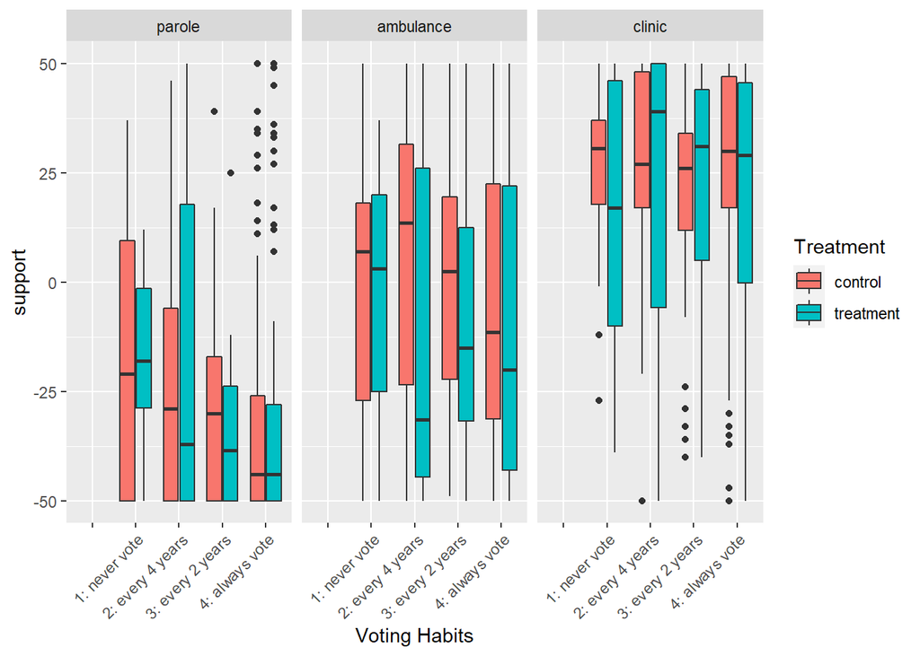

```r
treat.labs <- c("control", "treatment")
names(treat.labs) <- c(0, 1)

measure.labs <- c("parole", "ambulance", "clinic")
names(measure.labs) <- c("parole_Support", "ambulance_Support", "clinic_Support")


final_expanded %>%
  ggplot(aes(x=voting,y=support, fill=as.factor(treat))) +
  geom_boxplot() +
  xlab("Voting Habits")+
  facet_wrap(~measure,ncol = 3,labeller = labeller(measure=measure.labs)) +
  scale_fill_discrete(name="Treatment", labels=c("control", "treatment")) +
  theme(axis.text.x = element_text(angle = 45, hjust = 1))
```

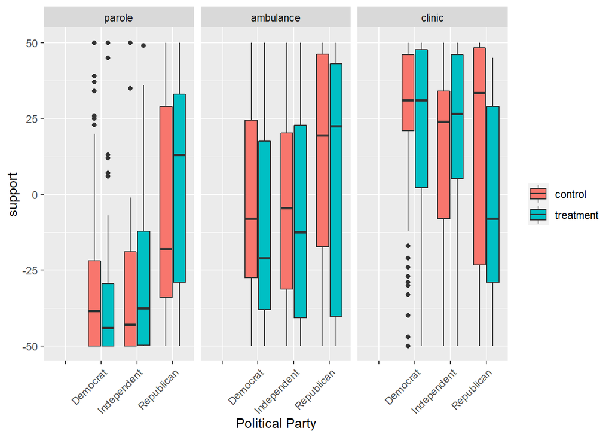

```r
measure.labs <- c("parole", "ambulance", "clinic")
names(measure.labs) <- c("parole_Support", "ambulance_Support", "clinic_Support")


final_expanded %>%
  filter(party != 'Other') %>%
  ggplot(aes(x=party,y=support, fill=as.factor(treat))) +
  geom_boxplot() +
  xlab("Political Party")+
  facet_wrap(~measure,ncol = 3,labeller = labeller(measure=measure.labs)) +
  scale_fill_discrete(name="", labels=c("control", "treatment")) +
  theme(axis.text.x = element_text(angle = 45, hjust = 1))
```

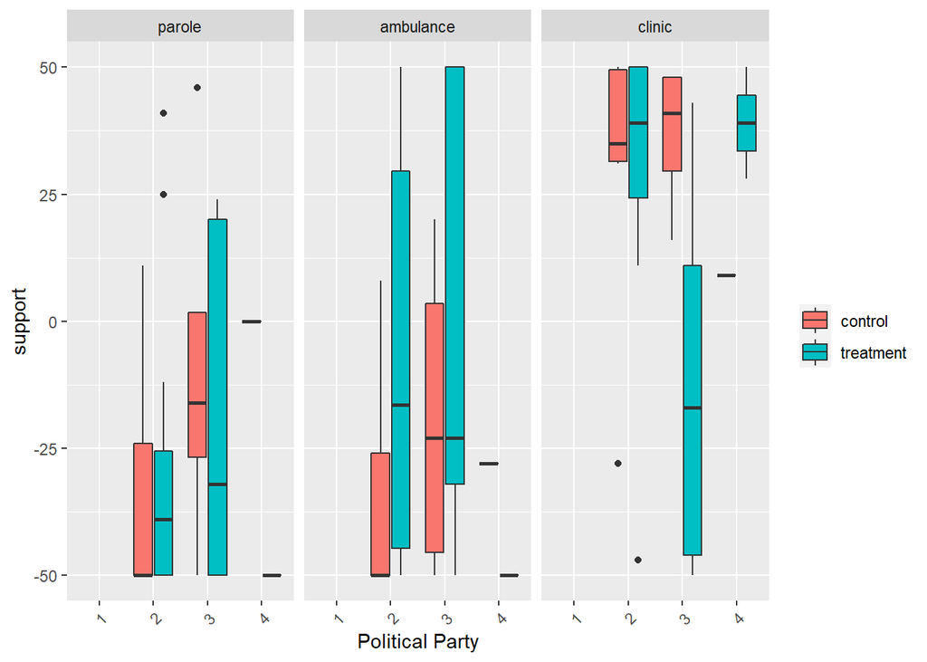

```r
measure.labs <- c("parole", "ambulance", "clinic")
names(measure.labs) <- c("parole_Support", "ambulance_Support", "clinic_Support")


pilot_expanded %>%
  filter(party != 'Other') %>%
  ggplot(aes(x=party,y=support, fill=as.factor(treat))) +
  geom_boxplot() +
  xlab("Political Party")+
  facet_wrap(~measure,ncol = 3,labeller = labeller(measure=measure.labs)) +
  scale_fill_discrete(name="", labels=c("control", "treatment")) +
  theme(axis.text.x = element_text(angle = 45, hjust = 1))
```

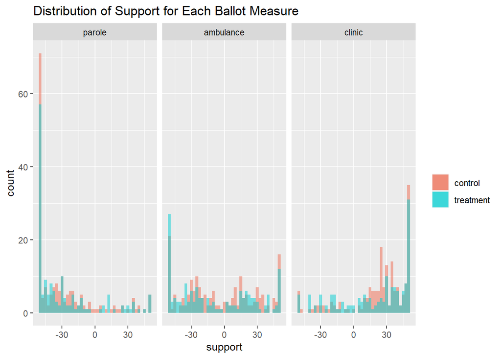

```r
ggplot(final_expanded, aes(x=support)) +
  geom_histogram(data = final_expanded[treat == 0], aes(fill = as.factor(treat)), alpha = 0.5, binwidth = 2.5) +
  geom_histogram(data = final_expanded[treat == 1], aes(fill = as.factor(treat)), alpha = 0.5, binwidth = 2.5) +
  scale_fill_manual(name="",values=c("coral2","darkturquoise"),labels=c("control","treatment")) +
  facet_wrap(~measure,ncol = 3,labeller = labeller(measure=measure.labs)) +
  ggtitle("Distribution of Support for Each Ballot Measure")
```

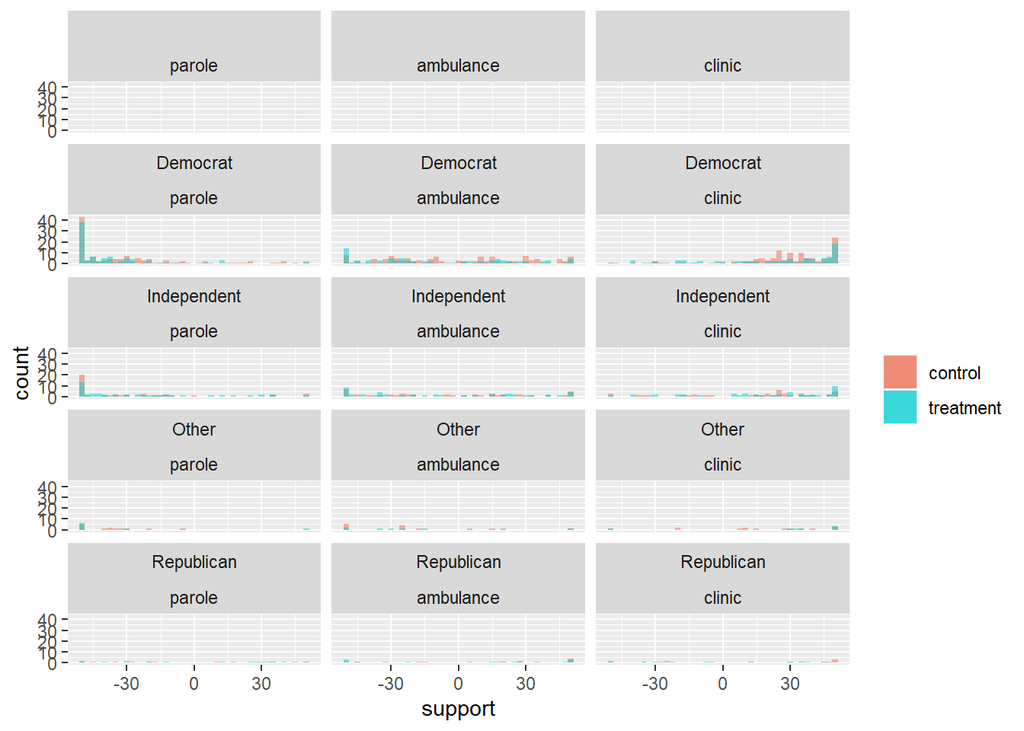

```r
ggplot(final_expanded, aes(x=support)) +
  geom_histogram(data = final_expanded[treat == 0], aes(fill = as.factor(treat)), alpha = 0.5, binwidth = 2.5) +
  geom_histogram(data = final_expanded[treat == 1], aes(fill = as.factor(treat)), alpha = 0.5, binwidth = 2.5) +
  scale_fill_manual(name="",values=c("coral2","darkturquoise"),labels=c("control","treatment")) +
  facet_wrap(party~measure,ncol = 3,labeller = labeller(measure=measure.labs))
```

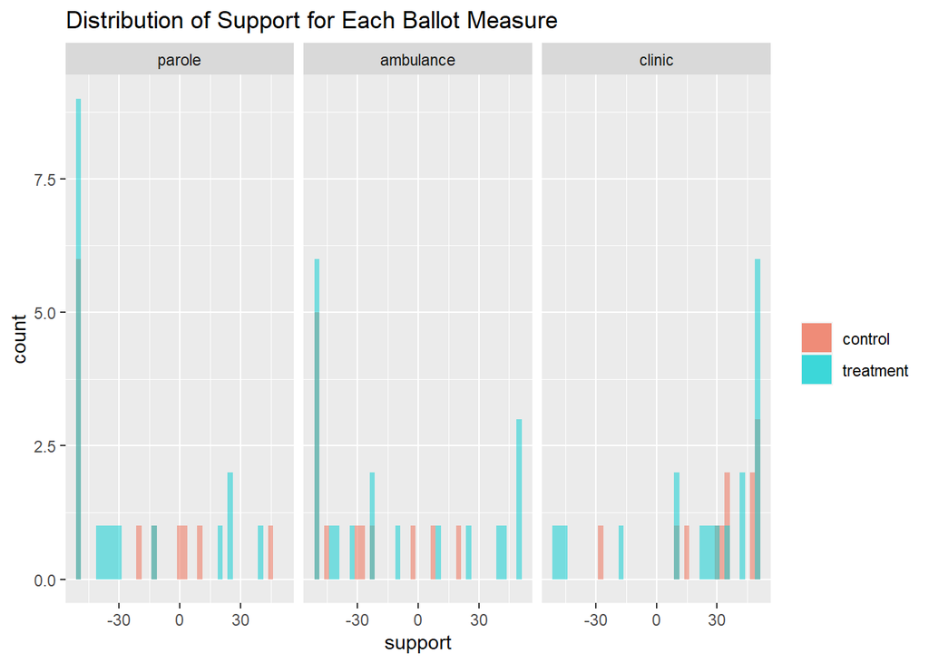

```r
ggplot(pilot_expanded, aes(x=support)) +
  geom_histogram(data = pilot_expanded[treat == 0], aes(fill = as.factor(treat)), alpha = 0.5, binwidth = 2.5) +
  geom_histogram(data = pilot_expanded[treat == 1], aes(fill = as.factor(treat)), alpha = 0.5, binwidth = 2.5) +
  scale_fill_manual(name="",values=c("coral2","darkturquoise"),labels=c("control","treatment")) +
  facet_wrap(~measure,ncol = 3,labeller = labeller(measure=measure.labs)) +
  ggtitle("Distribution of Support for Each Ballot Measure")
```

### Now we can create the models.

```r
mod_clustered1 <- lm(support ~ treat + measure, data = final_expanded)
#Add clustered standard errors
mod_clustered1$vcovCL1_ <- vcovCL(mod_clustered1, cluster = final_expanded[ , responseId])
coeftest(mod_clustered1, mod_clustered1$vcovCL1_)
```

```
##
## t test of coefficients:
##
##                          Estimate Std. Error  t value Pr(>|t|)
## (Intercept)              -27.4159     1.7432 -15.7269  < 2e-16 ***
## treat                     -3.1325     1.8294  -1.7123  0.08716 .
## measureambulance_Support  23.3291     2.0996  11.1111  < 2e-16 ***
## measureclinic_Support     50.0264     2.3762  21.0531  < 2e-16 ***
## ---
## Signif. codes:  0 '***' 0.001 '**' 0.01 '*' 0.05 '.' 0.1 ' ' 1
```

```r
mod_clustered2 <- lm(support ~ treat + measure + treat:measure, data = final_expanded)
#Add clustered standard errors
mod_clustered2$vcovCL1_ <- vcovCL(mod_clustered2, cluster = final_expanded[ , responseId])
coeftest(mod_clustered2, mod_clustered2$vcovCL1_)
```

```
##
## t test of coefficients:
##
##                                 Estimate Std. Error  t value Pr(>|t|)
## (Intercept)                    -28.78689    2.01860 -14.2608   <2e-16 ***
## treat                           -0.12161    3.06006  -0.0397   0.9683
## measureambulance_Support        25.78154    2.78386   9.2611   <2e-16 ***
## measureclinic_Support           51.66189    3.00291  17.2040   <2e-16 ***
## treat:measureambulance_Support  -5.40551    4.22616  -1.2791   0.2012
## treat:measureclinic_Support     -3.59549    4.83699  -0.7433   0.4575
## ---
## Signif. codes:  0 '***' 0.001 '**' 0.01 '*' 0.05 '.' 0.1 ' ' 1
```

```r
stargazer(
  mod_clustered1, mod_clustered2,
  type = 'text',
  se=list(sqrt(diag(mod_clustered1$vcovCL1_)),sqrt(diag(mod_clustered2$vcovCL1_))),
  header=F
  )
```

```
##
## =================================================================================
##                                               Dependent variable:
##                                --------------------------------------------------
##                                                     support
##                                           (1)                      (2)
## ---------------------------------------------------------------------------------
## treat                                   -3.132*                   -0.122
##                                         (1.829)                  (3.060)
##
## measureambulance_Support               23.329***                25.782***
##                                         (2.100)                  (2.784)
##
## measureclinic_Support                  50.026***                51.662***
##                                         (2.376)                  (3.003)
##
## treat:measureambulance_Support                                    -5.406
##                                                                  (4.226)
##
## treat:measureclinic_Support                                       -3.595
##                                                                  (4.837)
##
## Constant                              -27.416***                -28.787***
##                                         (1.743)                  (2.019)
##
## ---------------------------------------------------------------------------------
## Observations                             1,013                    1,013
## R2                                       0.320                    0.321
## Adjusted R2                              0.318                    0.318
## Residual Std. Error               29.866 (df = 1009)        29.875 (df = 1007)
## F Statistic                    158.336*** (df = 3; 1009) 95.232*** (df = 5; 1007)
## =================================================================================
## Note:                                                 *p<0.1; **p<0.05; ***p<0.01
```

## Power Calculation

Using the standard error for each measure, we can compute the power of this experiment. We can also compute the power based on the expanded dataset, which has three times the n. But, for the expanded dataset, the mean of the support variable is somewhat meaningless because it includes all three measures. Here are the four models we are interested in:

- mod_parole_simple
- mod_clinic_simple
- mod_ambulance_simple
- mod_clustered1

We need the treatment mean, control mean, standard errors, sample size for each model.

```r
#Parole info:
meanTreat_parole <- mean(final_sm[treat == 1, parole_Support], na.rm = T)
meanTreat_parole
```

```
## [1] -28.9085
```

```r
meanControl_parole <- mean(final_sm[treat == 0, parole_Support], na.rm = T)
meanControl_parole
```

```
## [1] -28.78689
```

```r
sampleSize_parole <- length(final_sm[parole_Attrite == 0, parole_Support])/2
sampleSize_parole
```

```
## [1] 168
```

```r
sigma(mod_parole_simple)
```

```
## [1] 27.81114
```

```r
#Ambulance info:
meanTreat_ambulance <- mean(final_sm[treat == 1, ambulance_Support], na.rm = T)
meanTreat_ambulance
```

```
## [1] -8.532468
```

```r
meanControl_ambulance <- mean(final_sm[treat == 0, ambulance_Support], na.rm = T)
meanControl_ambulance
```

```
## [1] -3.005348
```

```r
sampleSize_ambulance <- length(final_sm[ambulance_Attrite == 0, ambulance_Support])/2
sampleSize_ambulance
```

```
## [1] 170.5
```

```r
sigma(mod_ambulance_simple)
```

```
## [1] 33.15928
```

```r
#Clinic info:
meanTreat_clinic <- mean(final_sm[treat == 1, clinic_Support], na.rm = T)
meanTreat_clinic
```

```
## [1] 19.15789
```

```r
meanControl_clinic <- mean(final_sm[treat == 0, clinic_Support], na.rm = T)
meanControl_clinic
```

```
## [1] 22.875
```

```r
sampleSize_clinic <- length(final_sm[clinic_Attrite == 0, clinic_Support])/2
sampleSize_clinic
```

```
## [1] 168
```

```r
sigma(mod_clinic_simple)
```

```
## [1] 28.30873
```

```r
#Expanded info:
meanTreat_expanded <- mean(final_expanded[treat == 1, support], na.rm = T)
meanTreat_expanded
```

```
## [1] -6.154684
```

```r
meanControl_expanded <- mean(final_expanded[treat == 0, support], na.rm = T)
meanControl_expanded
```

```
## [1] -2.925993
```

```r
sampleSize_expanded <- nrow(final_expanded[!is.na(final_expanded$support)])/2
sampleSize_expanded
```

```
## [1] 506.5
```

```r
sigma(mod_clustered1)
```

```
## [1] 29.86606
```

Using the power calculation website, https://www.stat.ubc.ca/~rollin/stats/ssize/n2.html, here are the power answers for alpha=0.05.

```r
#Compute components for power of parole measure.
mu_parole_tx <- final_sm[treat==1, mean(parole_Support, na.rm=T)]
mu_parole_control <- final_sm[treat==0, mean(parole_Support, na.rm=T)]
parole_respondents1 <- final_sm[!is.na(parole_Support) & treat==1, .N]
parole_respondents0 <- final_sm[!is.na(parole_Support) & treat==0, .N]
parole_variance <- var(final_sm[,parole_Support], na.rm=T)
SE_parole <- summary(mod_parole_simple)$coefficients['treat',2]
SD_parole <- sqrt(parole_variance) #sqrt(parole_respondents)*SE_parole
ES_parole <- (mu_parole_tx - mu_parole_control)/SD_parole

#Compute components for power of ambulance measure.
mu_ambulance_tx <- final_sm[treat==1, mean(ambulance_Support, na.rm=T)]
mu_ambulance_control <- final_sm[treat==0, mean(ambulance_Support, na.rm=T)]
ambulance_respondents1 <- final_sm[!is.na(ambulance_Support) & treat==1, .N]
ambulance_respondents0 <- final_sm[!is.na(ambulance_Support) & treat==0, .N]
ambulance_variance <- var(final_sm[,ambulance_Support], na.rm=T)
# SE_parole <- summary(mod_parole_simple)$coefficients['treat',2]
SD_ambulance <- sqrt(ambulance_variance) #sqrt(parole_respondents)*SE_parole
ES_ambulance <- (mu_ambulance_tx - mu_ambulance_control)/SD_ambulance

#Compute components for power of clinic measure.
mu_clinic_tx <- final_sm[treat==1, mean(clinic_Support, na.rm=T)]
mu_clinic_control <- final_sm[treat==0, mean(clinic_Support, na.rm=T)]
clinic_respondents1 <- final_sm[!is.na(clinic_Support) & treat==1, .N]
clinic_respondents0 <- final_sm[!is.na(clinic_Support) & treat==0, .N]
clinic_variance <- var(final_sm[,clinic_Support], na.rm=T)
# SE_parole <- summary(mod_parole_simple)$coefficients['treat',2]
SD_clinic <- sqrt(clinic_variance) #sqrt(parole_respondents)*SE_parole
ES_clinic <- (mu_clinic_tx - mu_clinic_control)/SD_clinic

compute_power <- function(n1,n2,d,sig.level = 0.05,power) {
  computed_power = pwr.t2n.test(n1 = n1,n2 = n2,d = d,sig.level = sig.level, power = NULL)
  return(computed_power)
}

compute_ES <- function(n1,n2,d,sig.level = 0.05,power) {
  computed_ES = pwr.t2n.test(n1 = n1, n2 = n2, d = NULL, sig.level = 0.05, power = power)
  return(computed_ES)
}

compute_n <- function(n1,n2,d,sig.level = 0.05,power) {
  computed_n = pwr.t.test (n=NULL, d = d, power = power, type = "paired")
  return(computed_n)
}

parole_power <- compute_power(parole_respondents1,parole_respondents0,ES_parole, 0.05, .8)
parole_ES <- compute_ES(parole_respondents1,parole_respondents0,ES_parole, 0.05, .8)
parole_n <- compute_n(parole_respondents1,parole_respondents0,ES_parole, 0.05, .8)

ambulance_power <- compute_power(ambulance_respondents1,ambulance_respondents0,ES_ambulance, 0.05, .8)
ambulance_ES <- compute_ES(ambulance_respondents1,ambulance_respondents0,ES_ambulance, 0.05, .8)
ambulance_n <- compute_n(ambulance_respondents1,ambulance_respondents0,ES_ambulance, 0.05, .8)

clinic_power <- compute_power(clinic_respondents1,clinic_respondents0,ES_clinic, 0.05, .8)
clinic_ES <- compute_ES(clinic_respondents1,clinic_respondents0,ES_clinic, 0.05, .8)
clinic_n <- compute_n(clinic_respondents1,clinic_respondents0,ES_clinic, 0.05, .8)

parole_power
```

```
##
##      t test power calculation
##
##              n1 = 153
##              n2 = 183
##               d = 0.004379293
##       sig.level = 0.05
##           power = 0.05018204
##     alternative = two.sided
```

```r
parole_ES
```

```
##
##      t test power calculation
##
##              n1 = 153
##              n2 = 183
##               d = 0.30779
##       sig.level = 0.05
##           power = 0.8
##     alternative = two.sided
```

```r
parole_n
```

```
##
##      Paired t test power calculation
##
##               n = 409261.3
##               d = 0.004379293
##       sig.level = 0.05
##           power = 0.8
##     alternative = two.sided
##
## NOTE: n is number of *pairs*
```

```r
ambulance_power
```

```
##
##      t test power calculation
##
##              n1 = 154
##              n2 = 187
##               d = 0.1663549
##       sig.level = 0.05
##           power = 0.3318343
##     alternative = two.sided
```

```r
ambulance_ES
```

```
##
##      t test power calculation
##
##              n1 = 154
##              n2 = 187
##               d = 0.3057268
##       sig.level = 0.05
##           power = 0.8
##     alternative = two.sided
```

```r
ambulance_n
```

```
##
##      Paired t test power calculation
##
##               n = 285.5457
##               d = 0.1663549
##       sig.level = 0.05
##           power = 0.8
##     alternative = two.sided
##
## NOTE: n is number of *pairs*
```

```r
clinic_power
```

```
##
##      t test power calculation
##
##              n1 = 152
##              n2 = 184
##               d = 0.1312208
##       sig.level = 0.05
##           power = 0.2225808
##     alternative = two.sided
```

```r
clinic_ES
```

```
##
##      t test power calculation
##
##              n1 = 152
##              n2 = 184
##               d = 0.3079605
##       sig.level = 0.05
##           power = 0.8
##     alternative = two.sided
```

```r
clinic_n
```

```
##
##      Paired t test power calculation
##
##               n = 457.7529
##               d = 0.1312208
##       sig.level = 0.05
##           power = 0.8
##     alternative = two.sided
##
## NOTE: n is number of *pairs*
```

```r
mu_parole_tx
```

```
## [1] -28.9085
```

```r
mu_parole_control
```

```
## [1] -28.78689
```

```r
mu_clinic_tx
```

```
## [1] 19.15789
```

```r
mu_clinic_control
```

```
## [1] 22.875
```

```r
mu_ambulance_tx
```

```
## [1] -8.532468
```

```r
mu_ambulance_control
```

```
## [1] -3.005348
```

```r
dem_only <- final_sm[party == "Democrat"]
mu_parole_dem_tx <- dem_only[treat==1, mean(parole_Support, na.rm=T)]
mu_parole_dem_control <- dem_only[treat==0, mean(parole_Support, na.rm=T)]
parole_dem_respondents1 <- dem_only[!is.na(parole_Support) & treat==1, .N]
parole_dem_respondents0 <- dem_only[!is.na(parole_Support) & treat==0, .N]
parole_dem_variance <- var(dem_only[,parole_Support], na.rm=T)
SE_parole_dem <- summary(mod_parole_simple)$coefficients['treat',2]
SD_parole_dem <- sqrt(parole_dem_variance) #sqrt(parole_respondents)*SE_parole
ES_parole_dem <- (mu_parole_dem_tx - mu_parole_dem_control)/SD_parole_dem
# summary(dem_only)

parole_power_dem <- compute_power(parole_dem_respondents1,parole_dem_respondents0,ES_parole_dem, 0.05, .8)
parole_ES_dem <- compute_ES(parole_dem_respondents1,parole_dem_respondents0,ES_parole_dem, 0.05, .8)
parole_n_dem <- compute_n(parole_dem_respondents1,parole_dem_respondents0,ES_parole_dem, 0.05, .8)

parole_power_dem
```

```
##
##      t test power calculation
##
##              n1 = 87
##              n2 = 114
##               d = 0.212893
##       sig.level = 0.05
##           power = 0.3188468
##     alternative = two.sided
```

```r
parole_ES_dem
```

```
##
##      t test power calculation
##
##              n1 = 87
##              n2 = 114
##               d = 0.4007714
##       sig.level = 0.05
##           power = 0.8
##     alternative = two.sided
```

```r
parole_n_dem
```

```
##
##      Paired t test power calculation
##
##               n = 175.1048
##               d = 0.212893
##       sig.level = 0.05
##           power = 0.8
##     alternative = two.sided
##
## NOTE: n is number of *pairs*
```

```r
SD_parole_dem
```

```
## [1] 23.87812
```

```r
mod_pilot_parole <- lm(parole_Support ~ treat, data = pilot_sm)
mod_pilot_ambulance <- lm(ambulance_Support ~ treat, data = pilot_sm)
mod_pilot_clinic <- lm(clinic_Support ~ treat, data = pilot_sm)

stargazer(
  mod_pilot_parole, mod_pilot_ambulance, mod_pilot_clinic,
  type = 'text',
  header=F
  )
```

```
##
## =============================================================================
##                                             Dependent variable:
##                               -----------------------------------------------
##                               parole_Support ambulance_Support clinic_Support
##                                    (1)              (2)             (3)
## -----------------------------------------------------------------------------
## treat                             -4.934          18.368          -10.693
##                                  (11.671)        (13.202)         (11.459)
##
## Constant                        -22.750**       -29.000***       31.167***
##                                  (9.137)         (10.336)         (8.971)
##
## -----------------------------------------------------------------------------
## Observations                        31              31               31
## R2                                0.006            0.063           0.029
## Adjusted R2                       -0.028           0.030           -0.004
## Residual Std. Error (df = 29)     31.652          35.803           31.077
## F Statistic (df = 1; 29)          0.179            1.936           0.871
## =============================================================================
## Note:                                             *p<0.1; **p<0.05; ***p<0.01
```

```r
#Parole info:
meanTreat_Pilot_parole <- mean(pilot_sm[treat == 1, parole_Support], na.rm = T)
meanTreat_Pilot_parole
```

```
## [1] -27.68421
```

```r
meanControl_Pilot_parole <- mean(pilot_sm[treat == 0, parole_Support], na.rm = T)
meanControl_Pilot_parole
```

```
## [1] -22.75
```

```r
sampleSize_Pilot_parole <- 31
sampleSize_Pilot_parole
```

```
## [1] 31
```

```r
sigma(mod_pilot_parole)
```

```
## [1] 31.6524
```

```r
#Ambulance info:
meanTreat_Pilot_ambulance <- mean(pilot_sm[treat == 1, ambulance_Support], na.rm = T)
meanTreat_Pilot_ambulance
```

```
## [1] -10.63158
```

```r
meanControl_Pilot_ambulance <- mean(pilot_sm[treat == 0, ambulance_Support], na.rm = T)
meanControl_Pilot_ambulance
```

```
## [1] -29
```

```r
sampleSize_Pilot_ambulance <- 31
sampleSize_Pilot_ambulance
```

```
## [1] 31
```

```r
sigma(mod_pilot_ambulance)
```

```
## [1] 35.8033
```

```r
#Clinic info:
meanTreat_Pilot_clinic <- mean(pilot_sm[treat == 1, clinic_Support], na.rm = T)
meanTreat_Pilot_clinic
```

```
## [1] 20.47368
```

```r
meanControl_Pilot_clinic <- mean(pilot_sm[treat == 0, clinic_Support], na.rm = T)
meanControl_Pilot_clinic
```

```
## [1] 31.16667
```

```r
sampleSize_Pilot_clinic <- 31
sampleSize_Pilot_clinic
```

```
## [1] 31
```

```r
sigma(mod_pilot_clinic)
```

```
## [1] 31.07744
```

```r
#Compute components for power of parole measure.
mu_parole_tx_pilot <- pilot_sm[treat==1, mean(parole_Support, na.rm=T)]
mu_parole_control_pilot <- pilot_sm[treat==0, mean(parole_Support, na.rm=T)]
parole_respondents1_pilot <- pilot_sm[!is.na(parole_Support) & treat==1, .N]
parole_respondents0_pilot <- pilot_sm[!is.na(parole_Support) & treat==0, .N]
parole_variance_pilot <- var(pilot_sm[,parole_Support], na.rm=T)
SD_parole_pilot <- sqrt(parole_variance_pilot)
ES_parole_pilot <- (mu_parole_tx_pilot - mu_parole_control_pilot)/SD_parole_pilot

#Compute components for power of ambulance measure.
mu_ambulance_tx_pilot <- pilot_sm[treat==1, mean(ambulance_Support, na.rm=T)]
mu_ambulance_control_pilot <- pilot_sm[treat==0, mean(ambulance_Support, na.rm=T)]
ambulance_respondents1_pilot <- pilot_sm[!is.na(ambulance_Support) & treat==1, .N]
ambulance_respondents0_pilot <- pilot_sm[!is.na(ambulance_Support) & treat==0, .N]
ambulance_variance_pilot <- var(pilot_sm[,ambulance_Support], na.rm=T)
SD_ambulance_pilot <- sqrt(ambulance_variance_pilot)
ES_ambulance_pilot <- (mu_ambulance_tx_pilot - mu_ambulance_control_pilot)/SD_ambulance_pilot

#Compute components for power of clinic measure.
mu_clinic_tx_pilot <- pilot_sm[treat==1, mean(clinic_Support, na.rm=T)]
mu_clinic_control_pilot <- pilot_sm[treat==0, mean(clinic_Support, na.rm=T)]
clinic_respondents1_pilot <- pilot_sm[!is.na(clinic_Support) & treat==1, .N]
clinic_respondents0_pilot <- pilot_sm[!is.na(clinic_Support) & treat==0, .N]
clinic_variance_pilot <- var(pilot_sm[,clinic_Support], na.rm=T)
SD_clinic_pilot <- sqrt(clinic_variance_pilot)
ES_clinic_pilot <- (mu_clinic_tx_pilot - mu_clinic_control_pilot)/SD_clinic_pilot

parole_power_pilot <- compute_power(parole_respondents1_pilot,parole_respondents0_pilot,ES_parole_pilot, 0.05, .8)
parole_ES_pilot <- compute_ES(parole_respondents1_pilot,parole_respondents0_pilot,ES_parole_pilot, 0.05, .8)
parole_n_pilot <- compute_n(parole_respondents1_pilot,parole_respondents0_pilot,ES_parole_pilot, 0.05, .8)

ambulance_power_pilot <- compute_power(ambulance_respondents1_pilot,ambulance_respondents0_pilot,ES_ambulance_pilot, 0.05, .8)
ambulance_ES_pilot <- compute_ES(ambulance_respondents1_pilot,ambulance_respondents0_pilot,ES_ambulance_pilot, 0.05, .8)
ambulance_n_pilot <- compute_n(ambulance_respondents1_pilot,ambulance_respondents0_pilot,ES_ambulance_pilot, 0.05, .8)

clinic_power_pilot <- compute_power(clinic_respondents1_pilot,clinic_respondents0_pilot,ES_clinic_pilot, 0.05, .8)
clinic_ES_pilot <- compute_ES(clinic_respondents1_pilot,clinic_respondents0_pilot,ES_clinic_pilot, 0.05, .8)
clinic_n_pilot <- compute_n(clinic_respondents1_pilot,clinic_respondents0_pilot,ES_clinic_pilot, 0.05, .8)

parole_power_pilot
```

```
##
##      t test power calculation
##
##              n1 = 19
##              n2 = 12
##               d = 0.158066
##       sig.level = 0.05
##           power = 0.0699191
##     alternative = two.sided
```

```r
parole_ES_pilot
```

```
##
##      t test power calculation
##
##              n1 = 19
##              n2 = 12
##               d = 1.068861
##       sig.level = 0.05
##           power = 0.8
##     alternative = two.sided
```

```r
parole_n_pilot
```

```
##
##      Paired t test power calculation
##
##               n = 316.0707
##               d = 0.158066
##       sig.level = 0.05
##           power = 0.8
##     alternative = two.sided
##
## NOTE: n is number of *pairs*
```

```r
ambulance_power_pilot
```

```
##
##      t test power calculation
##
##              n1 = 19
##              n2 = 12
##               d = 0.5052175
##       sig.level = 0.05
##           power = 0.2632237
##     alternative = two.sided
```

```r
ambulance_ES_pilot
```

```
##
##      t test power calculation
##
##              n1 = 19
##              n2 = 12
##               d = 1.068861
##       sig.level = 0.05
##           power = 0.8
##     alternative = two.sided
```

```r
ambulance_n_pilot
```

```
##
##      Paired t test power calculation
##
##               n = 32.72303
##               d = 0.5052175
##       sig.level = 0.05
##           power = 0.8
##     alternative = two.sided
##
## NOTE: n is number of *pairs*
```

```r
clinic_power_pilot
```

```
##
##      t test power calculation
##
##              n1 = 19
##              n2 = 12
##               d = 0.3448192
##       sig.level = 0.05
##           power = 0.1476822
##     alternative = two.sided
```

```r
clinic_ES_pilot
```

```
##
##      t test power calculation
##
##              n1 = 19
##              n2 = 12
##               d = 1.068861
##       sig.level = 0.05
##           power = 0.8
##     alternative = two.sided
```

```r
clinic_n_pilot
```

```
##
##      Paired t test power calculation
##
##               n = 67.95788
##               d = 0.3448192
##       sig.level = 0.05
##           power = 0.8
##     alternative = two.sided
##
## NOTE: n is number of *pairs*
```

```r
mu_parole_tx_pilot
```

```
## [1] -27.68421
```

```r
mu_parole_control_pilot
```

```
## [1] -22.75
```

```r
mu_clinic_tx_pilot
```

```
## [1] 20.47368
```

```r
mu_clinic_control_pilot
```

```
## [1] 31.16667
```

```r
mu_ambulance_tx_pilot
```

```
## [1] -10.63158
```

```r
mu_ambulance_control_pilot
```

```
## [1] -29
```

```r
get_n_values <- function(d, power_values) {
  n_values <- c()
  power_vals <- c()
  for (power_value in power_values) {
    power_value
    power_test <- pwr.t.test(n=NULL, d = d, power = power_value, type = "paired")
    if(power_test$n < 500) {
      n_values <- append(n_values,power_test$n)
      power_vals <- append(power_vals,power_value)
    }
  }
  return(data.table(n_values,power_vals))
}

power_values <- seq(from=.1, to=1, by=.05)
parole_power_values <- seq(from=.01, to=.5, by=.01)
#The sample size for parole are too high, so don't plot them. Effect size is too tiny.
# pwr.t.test(n=NULL, d = parole_n$d, power = .06, type = "paired")
# parolePowerPlot <- get_n_values(parole_n$d,parole_power_values)
# parolePowerPlot[,measure := "parole"]
parolePowerPlot <- data.table(n_values = c(50,(parole_power$n1+parole_power$n2)/2,500),
                              power_vals = c(parole_power$power*.99,
                                             parole_power$power,
                                             parole_power$power*1.01),
                              measure = c("parole","parole","parole"),
                              pilot = c("0","0","0"))
parolePowerPlot
```

| n_values | power_vals | measure | pilot |
| --- | --- | --- | --- |
| 50 | 0.04968022 | parole | 0 |
| 168 | 0.05018204 | parole | 0 |
| 500 | 0.05068386 | parole | 0 |

```r
clinicPowerPlot <- get_n_values(clinic_n$d,power_values)
clinicPowerPlot[,measure := "clinic"][, pilot := "0"]

ambulancePowerPlot <- get_n_values(ambulance_n$d,power_values)
ambulancePowerPlot[,measure := "ambulance"][, pilot := "0"]

parolePowerPlot_pilot <- get_n_values(parole_n_pilot$d,power_values)
parolePowerPlot_pilot[,measure := "parole_pilot"][, pilot := "1"]

clinicPowerPlot_pilot <- get_n_values(clinic_n_pilot$d,power_values)
clinicPowerPlot_pilot[,measure := "clinic_pilot"][, pilot := "1"]

ambulancePowerPlot_pilot <- get_n_values(ambulance_n_pilot$d,power_values)
ambulancePowerPlot_pilot[,measure := "ambulance_pilot"][, pilot := "1"]

power_plot <- rbind(parolePowerPlot,
                    ambulancePowerPlot,
                    clinicPowerPlot,
                    parolePowerPlot_pilot,
                    ambulancePowerPlot_pilot,
                    clinicPowerPlot_pilot)
```

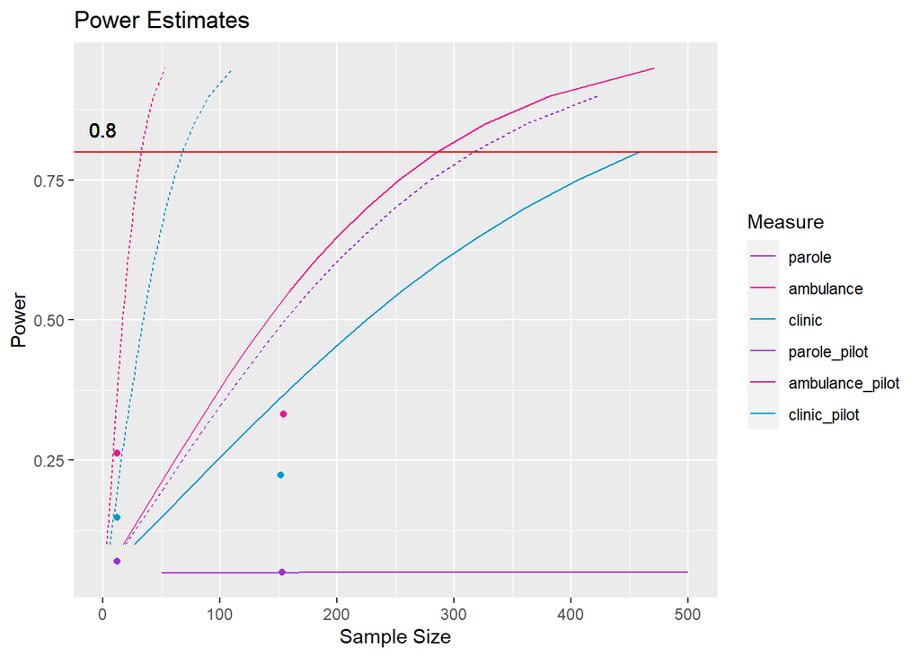

| measure | sample size (T/C) | effect size | power | sample for 80% power |
| --- | --- | --- | --- | --- |
| parole pilot | 19/12 | 0.1581 | 0.07 | 316 |
| ambulance pilot | 19/12 | 0.5052 | 0.263 | 33 |
| clinic pilot | 19/12 | 0.3448 | 0.148 | 68 |
| parole | 153/183 | 0.0044 | 0.05 | 409261 |
| ambulance | 154/187 | 0.1664 | 0.332 | 286 |
| clinic | 152/184 | 0.1312 | 0.223 | 458 |

```r
p <- 0.8

ggplot(data=power_plot, aes(x=n_values, y=power_vals, group=measure)) +
  geom_line(aes(color=measure, linetype=pilot)) +
  labs(x = "Sample Size", y = "Power") +
  scale_color_manual(breaks=c("parole","ambulance","clinic",
                              "parole_pilot", "ambulance_pilot", "clinic_pilot"),
                     values=c("darkorchid3", "deeppink2", "deepskyblue3",
                              "darkorchid3", "deeppink2", "deepskyblue3")) +
  guides(color=guide_legend("Measure"), linetype=F) +
  geom_abline(slope = 0, intercept = .8, color = "red") +
  geom_text(aes(0,p,label = p, vjust = -1)) +

  geom_point(aes(x=153, y=.05), color="darkorchid3") +
  geom_point(aes(x=154, y=.332), color="deeppink2") +
  geom_point(aes(x=152, y=.223), color="deepskyblue3") +
  geom_point(aes(x=12, y=.07), color="darkorchid3") +
  geom_point(aes(x=12, y=.263), color="deeppink2") +
  geom_point(aes(x=12, y=.148), color="deepskyblue3") +
  ggtitle("Power Estimates")
```